# P1: Stroop Effect

Adittya September 2018

## Introudction

In a Stroop task, participants are presented with a list of words, with each word displayed in a color of ink. The participant’s task is to say out loud the color of the ink in which the word is printed. The task has two conditions: a congruent words condition, and an incongruent words condition. In the congruent words condition, the words being displayed are color words whose names match the colors in which they are printed: for example RED, BLUE. In the incongruent words condition, the words displayed are color words whose names do not match the colors in which they are printed: for example PURPLE, ORANGE. In each case, we measure the time it takes to name the ink colors in equally-sized lists. Each participant will go through and record a time from each condition.

### (1) What is our independent variable? What is our dependent variable?

- Our independent variable is the type of condition applied to the student, either the congruent condition or the incongruent condition.
- Our dependent variable is the time in seconds that it takes for the participant to name the ink colors in the list.

### (2) What is an appropriate set of hypotheses for this task? Specify the null and alternative hypotheses based on what you think the researchers might be interested in. Justify your choices.

The following will be the appropriate set of hypothesis in order to determine if the mean difference between the two conditions is statistically significant:

- Null Hypothsis, H0 - The incongruent words will have no significant effect in the time taken to recognize and say the color than the time taken for congruent words.
- Alternate Hypothesis, H1 - The incongruent words will result in significantly increased time to recognize and say the color than the time taken for congruent words.

H0: μi ≤ μc (μi - population mean of incongruent values, μc - population mean of congruent values)

H1: μi > μc (μi - population mean of incongruent values, μc - population mean of congruent values)

### (3) Report some descriptive statistics regarding this dataset. Include at least one measure of central tendency and at least one measure of variability.

sample size = 24

```r
df <- read.csv('stroopdata.csv')

df
```

| Congruent | Incongruent |
| --- | --- |
| 12.079 | 19.278 |
| 16.791 | 18.741 |
| 9.564 | 21.214 |
| 8.630 | 15.687 |
| 14.669 | 22.803 |
| 12.238 | 20.878 |
| 14.692 | 24.572 |
| 8.987 | 17.394 |
| 9.401 | 20.762 |
| 14.480 | 26.282 |

[output cut: 14 more lines]

#### Mean, Median, Standard Deviation and Variation:

First, lets tidy the data such that each variable is a column, and each observation is a row (store it as cleandf) to make the visulization easier. [4]

```r
library(tidyr)
library(dplyr)
dftemp <- mutate(df, subject=1:nrow(df))
cleandf <- gather(dftemp, congruency, time, -subject)

cleandf %>%
  group_by(congruency) %>%
  summarise(mean(time),median(time),sd(time),var(time))
```

| congruency | mean(time) | median(time) | sd(time) | var(time) |
| --- | --- | --- | --- | --- |
| Congruent | 14.05113 | 14.3565 | 3.559358 | 12.66903 |
| Incongruent | 22.01592 | 21.0175 | 4.797057 | 23.01176 |

### (4) Provide one or two visualizations that show the distribution of the sample data. Write one or two sentences noting what you observe about the plot or plots.

The distribution of data from both congruent and incongruent conditions can be visualised using boxplot and smoothed histogram(Kernel density plot)

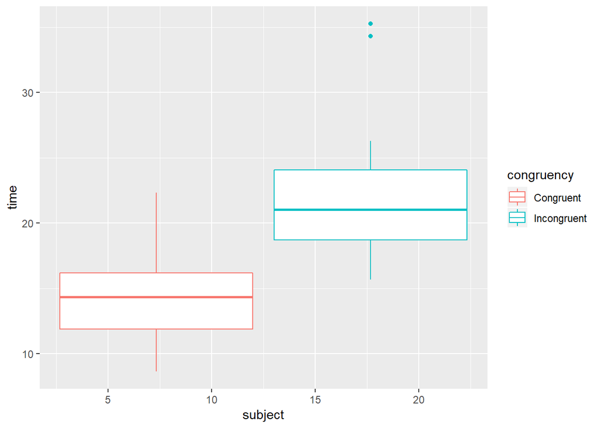

```r
library(ggplot2)

ggplot(data = cleandf, aes(x = subject, y = time, color = congruency)) +
  geom_boxplot()
```

From the boxplot, there are two outliers or extraneous data which skews the mean of incongruent values.

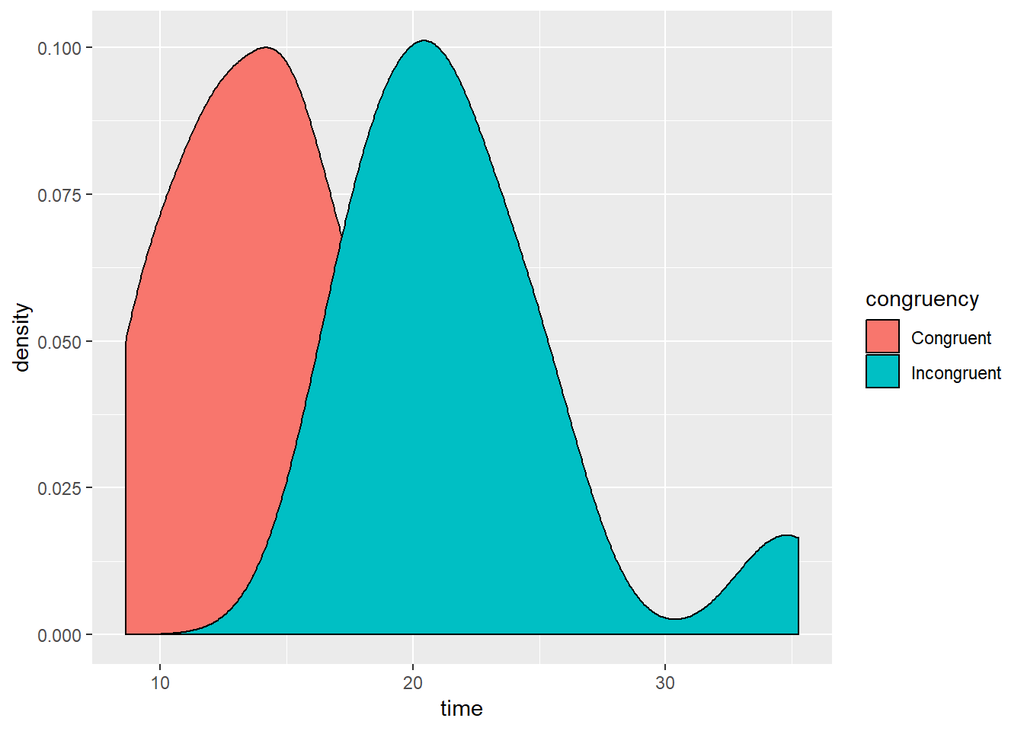

```r
ggplot(data = cleandf, aes(x = time, fill = congruency)) +
  geom_density()
```

In the kernel density plot, although both graphs visually appear somewhat positively skewed, the mean is pretty close to the peak in both graphs which indicates a normal distribution.

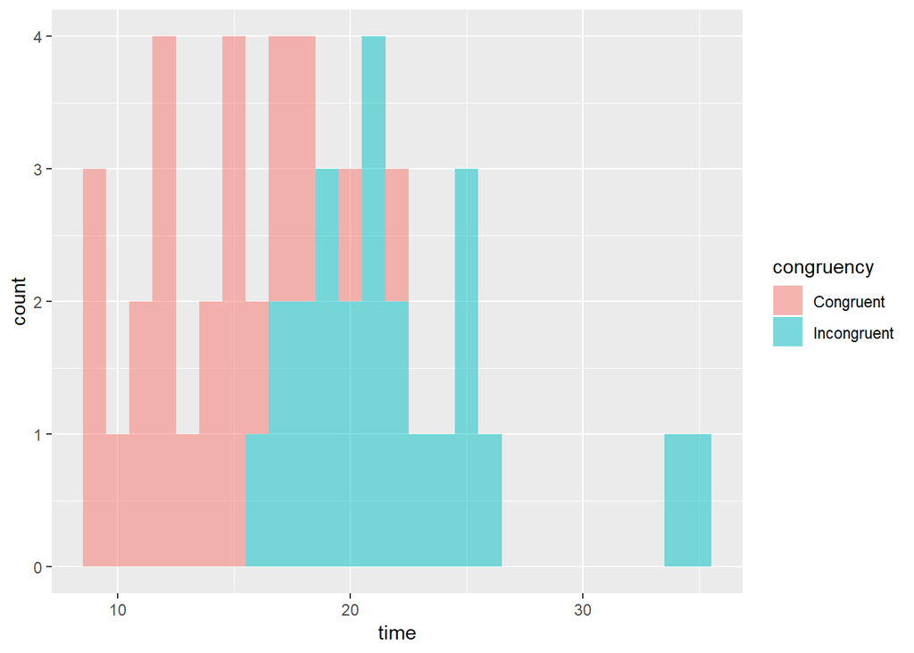

```r
ggplot(data = cleandf, aes(x = time, fill = congruency)) +
  geom_histogram(alpha = 0.5, binwidth = 1)
```

```r
t.test(df$Congruent, df$Incongruent)
```

```
##
##  Welch Two Sample t-test
##
## data:  df$Congruent and df$Incongruent
## t = -6.5323, df = 42.434, p-value = 6.51e-08
## alternative hypothesis: true difference in means is not equal to 0
## 95 percent confidence interval:
##  -10.424698  -5.504885
## sample estimates:
## mean of x mean of y
##  14.05113  22.01592
```

### (6) What do you think is responsible for the effects observed? Can you think of an alternative or similar task that would result in a similar effect? Some research about the problem will be helpful for thinking about these two questions!

The following theories explain the effects observed[1]:

- Processing speed: This theory suggests there is a lag in the brain’s ability to recognize the color of the word since the brain reads words faster than it recognizes colors
- Selective attention:The Selective Attention Theory suggests that color recognition, as opposed to reading a word, requires more attention. The brain needs to use more attention to recognize a color than to encode a word, so it takes a little longer.[17] The responses lend much to the interference noted in the Stroop task. This may be a result of either an allocation of attention to the responses or to a greater inhibition of distractors that are not appropriate responses.
- Automaticity: It suggests that since recognizing colors is not an “automatic process” there is hesitancy to respond; whereas, the brain automatically understands the meaning of words as a result of habitual reading. This idea is based on the premise that automatic reading does not need controlled attention, but still uses enough attentional resources to reduce the amount of attention accessible for color information processing. This is the most common theory of the Stroop effect.
- Parallel distributed processing: This theory suggests that as the brain analyzes information, different and specific pathways are developed for different tasks. Some pathways, such as reading, are stronger than others, therefore, it is the strength of the pathway and not the speed of the pathway that is important.

The Simon effect is a similar task which would result in a similar effect. [2]

In Simon’s original study, two lights (the stimulus) were placed on a rotating circular panel. This device would be rotated at varying degrees (away from the horizontal plane). Simon wished to see if an alteration of the spatial relationship, relative to the response keys, affected performance. Age was also a probable factor in reaction time. As predicted the reaction time of the groups increased based on the relative position of the light stimulus (age was not a factor). The reaction time increased by as much as 30%. (Simon & Wolf, 1963).

#### References

[1] https://en.wikipedia.org/wiki/Stroop_effect#Theories [2] https://en.wikipedia.org/wiki/Simon_effect [3] https://ggplot2.tidyverse.org/ [4] https://tidyr.tidyverse.org/